# Final_Project_RMarkdown

Registration: 230243318

2024-03-19

# **The number and distribution of adult rape cases in England and Wales from 2016-2022.**

## 1. Background and Research Questions

For this project, I was curious as to how the number of rape cases per 100,000 people has evolved by geographical area over the years in England and Wales.Specifically, from 2016 - 2022. It would also be interesting to explore how the number of cases differ pre and post COVID-19. Therefore, the questions is:

*What are the trends in adult rape offences from the year 2016 to 2022.*

## 2. Data Origins

I found this data set on the official Criminal Justice System’s website *(https://criminal-justice-delivery-data-dashboards.justice.gov.uk/rape-review)*. The data was collected by various departments such as the police, Crown Prosecution Services, the courts (HMCTS), Home Office, and Ministry of Justice.

The data variables consist of the offence type, the stage the case is at (either recorded at the decision of the police, police referral, or at completion in court), the priority area (this states whether the data was recorded to improve the quality of justice, time spent on cases, increasing victim engagement, or as part of a review to better adjust the aims of the relevant departments), metric name, geographical granularity (who had jurisdiction by area), geographic area name (where the cases were recorded), date granularity (whether the data was recorded quarterly or annually), time period (when it was recorded in regard to the date granularity), the number of cases and a column of reasons for any missing data (which is empty).

It is noteworthy to mention that website does not specify how the data was collected because it is collected by multiple people within the various departments, each having their own protocols. However, one can find detailed descriptions from each department in their version of a code book.

## 3. A Glimpse At The Data

The first step I took was to ensure that I had all the necessary packages loaded into RStudio and set my “here” function to make sure that it would be able to locate the data set.

```r
# Installing the packages and defining "here"
library(here)
library(tidyverse)
library(knitr)
library(mapdata)
library(maps)
library(ggplot2)
library(dplyr)
library(shiny)
library(gganimate)
library(plotly)
```

3.1 Below is a brief overview of the raw data using the head function.

```r
# Head of raw data
data1 <- here("data", "raw_data.csv")
raw_data <- read.csv(data1)
head(raw_data)
```

```
##   offence_type                             stage                priority_area
## 1   Adult rape Crime recorded to police decision Improving quality of justice
## 2   Adult rape Crime recorded to police decision Improving quality of justice
## 3   Adult rape Crime recorded to police decision Improving quality of justice
## 4   Adult rape Crime recorded to police decision Improving quality of justice
## 5   Adult rape Crime recorded to police decision Improving quality of justice
## 6   Adult rape Crime recorded to police decision Improving quality of justice
##                                                 metric_name
## 1 Cases the police refer to the CPS for a charging decision
## 2 Cases the police refer to the CPS for a charging decision
## 3 Cases the police refer to the CPS for a charging decision
## 4 Cases the police refer to the CPS for a charging decision
## 5 Cases the police refer to the CPS for a charging decision
## 6 Cases the police refer to the CPS for a charging decision
##   geographic_granularity geographic_area_name date_granularity    time_period
## 1               National             National        Quarterly Apr - Jun 2018
## 2               National             National        Quarterly Jul - Sep 2018
## 3               National             National        Quarterly Oct - Dec 2018
## 4               National             National        Quarterly Jan - Mar 2019
## 5               National             National        Quarterly Apr - Jun 2019
## 6               National             National        Quarterly Jul - Sep 2019
##   value reason_for_missing_data
## 1   575
## 2   617
## 3   613
## 4   501
## 5   482
## 6   444
```

3.2

The graph did not look good when i knitted it, so I am using this code to better fit the webpage.

```r
#Better fitting the head table
raw_head <- function(raw_data) {
  if (knitr::is_html_output()) {
    return(knitr::kable(raw_data, format = "html", table.attr = "style='width:100%'"))
  } else if (knitr::is_latex_output()){
    return(knitr::kable(raw_data))
  }
}

raw_head(head(raw_data))
```

| offence_type | stage | priority_area | metric_name | geographic_granularity | geographic_area_name | date_granularity | time_period | value | reason_for_missing_data |
| --- | --- | --- | --- | --- | --- | --- | --- | --- | --- |
| Adult rape | Crime recorded to police decision | Improving quality of justice | Cases the police refer to the CPS for a charging decision | National | National | Quarterly | Apr - Jun 2018 | 575 |  |
| Adult rape | Crime recorded to police decision | Improving quality of justice | Cases the police refer to the CPS for a charging decision | National | National | Quarterly | Jul - Sep 2018 | 617 |  |
| Adult rape | Crime recorded to police decision | Improving quality of justice | Cases the police refer to the CPS for a charging decision | National | National | Quarterly | Oct - Dec 2018 | 613 |  |
| Adult rape | Crime recorded to police decision | Improving quality of justice | Cases the police refer to the CPS for a charging decision | National | National | Quarterly | Jan - Mar 2019 | 501 |  |
| Adult rape | Crime recorded to police decision | Improving quality of justice | Cases the police refer to the CPS for a charging decision | National | National | Quarterly | Apr - Jun 2019 | 482 |  |
| Adult rape | Crime recorded to police decision | Improving quality of justice | Cases the police refer to the CPS for a charging decision | National | National | Quarterly | Jul - Sep 2019 | 444 |  |

## 4. Data Preparation

4.1 For the purposes of this project, I decided to filter the data to recorded adult rape offences per 100,000 population on a rolling annual basis from the year 2016-2022. To make it easier to visualise the data on a map I also filtered it by police force area. The below head function provides a preview to the filtered data. The data that will be used for the visualisation now only include the following columns: offence type, metric name, geographic area name, time period and value.

```r
# Filtering the raw data so that it only contains the variables that I am interested in.
filtered_data <- raw_data %>%
  select("offence_type", "metric_name", "geographic_area_name", "time_period", "value")

# Filtering further columns so that I only have specific variables.

# Metric_name
filtered_data <- filtered_data %>%
  filter(metric_name == "Recorded adult rape offences (per 100,000 population)")

# Geographic_area_name
filtered_data <- filtered_data %>%
  filter(geographic_area_name %in% c("Avon and Somerset", "Bedfordshire", "Cambridgeshire", "Cheshire", "City of London Police", "Cleveland", "Cumbria", "Derbyshire", "Devon and Cornwall", "Dorset", "Durham", "Dyfed-Powys", "Essex", "Gloucestershire", "Greater Manchester", "Gwent", "Hampshire", "Hertfordshire", "Humberside", "Kent", "Lancashire", "Leicestershire", "Lincolnshire", "Merseyside", "Metropolitan Police", "Norfolk", "North Wales", "North Yorkshire", "Northamptonshire", "Northumbria", "Nottinghamshire", "South Wales", "South Yorkshire", "Staffordshire", "Suffolk", "Surrey", "Sussex", "Thames Valley", "Warwickshire", "West Mercia", "West Midlands", "West Yorkshire", "Wiltshire"))

# Time_period
filtered_data <- filtered_data %>%
  filter(time_period %in% c("Jan 2016 - Dec 2016", "Jan 2017 - Dec 2017", "Jan 2018 - Dec 2018", "Jan 2019 - Dec 2019", "Jan 2020 - Dec 2020", "Jan 2021 - Dec 2021", "Jan 2022 - Dec 2022"))

# Change the time period so it is just a numeric variable
filtered_data <- filtered_data %>%
  mutate(time_period = ifelse(
    time_period == "Jan 2016 - Dec 2016", "2016",
    ifelse(
      time_period == "Jan 2017 - Dec 2017", "2017",
      ifelse(
        time_period == "Jan 2018 - Dec 2018", "2018",
        ifelse(
          time_period == "Jan 2019 - Dec 2019", "2019",
          ifelse(
            time_period == "Jan 2020 - Dec 2020", "2020",
            ifelse(
              time_period == "Jan 2021 - Dec 2021", "2021",
              ifelse(
                time_period == "Jan 2022 - Dec 2022", "2022",
                time_period
              )
            )
          )
        )
      )
    )
  ))


head(filtered_data)
```

```
##   offence_type                                           metric_name
## 1   Adult rape Recorded adult rape offences (per 100,000 population)
## 2   Adult rape Recorded adult rape offences (per 100,000 population)
## 3   Adult rape Recorded adult rape offences (per 100,000 population)
## 4   Adult rape Recorded adult rape offences (per 100,000 population)
## 5   Adult rape Recorded adult rape offences (per 100,000 population)
## 6   Adult rape Recorded adult rape offences (per 100,000 population)
##   geographic_area_name time_period    value
## 1    Avon and Somerset        2016 60.23634
## 2    Avon and Somerset        2017 78.69124
## 3    Avon and Somerset        2018 70.78199
## 4    Avon and Somerset        2019 71.69901
## 5    Avon and Somerset        2020 65.62379
## 6    Avon and Somerset        2021 80.75452
```

4.2 Again, the graph did not look great when I knitted it, so here is a code that will help it look better.

```r
#Better fitting the head table
filtered_head <- function(filtered_data) {
  if (knitr::is_html_output()) {
    return(knitr::kable(filtered_data, format = "html", table.attr = "style='width:100%'"))
  } else if (knitr::is_latex_output()){
    return(knitr::kable(raw_data))
  }
}

filtered_head(head(filtered_data))
```

| offence_type | metric_name | geographic_area_name | time_period | value |
| --- | --- | --- | --- | --- |
| Adult rape | Recorded adult rape offences (per 100,000 population) | Avon and Somerset | 2016 | 60.23634 |
| Adult rape | Recorded adult rape offences (per 100,000 population) | Avon and Somerset | 2017 | 78.69124 |
| Adult rape | Recorded adult rape offences (per 100,000 population) | Avon and Somerset | 2018 | 70.78199 |
| Adult rape | Recorded adult rape offences (per 100,000 population) | Avon and Somerset | 2019 | 71.69901 |
| Adult rape | Recorded adult rape offences (per 100,000 population) | Avon and Somerset | 2020 | 65.62379 |
| Adult rape | Recorded adult rape offences (per 100,000 population) | Avon and Somerset | 2021 | 80.75452 |

4.3 To be able to map my data onto a map of England and Wales I needed to get geographical coordinates for the respective police force areas. I was able to download them at *https://open-geography-portalx-ons.hub.arcgis.com/datasets/ons::police-force-areas-december-2018-generalised-clipped-boundaries-ew/explore?showTable=true*.I also had to change the names of two geographical area so they would match the names in the filtered data set.

```r
# Loading UK police force area coordinates
police_force_areas <- here("data", "Police_Force_Areas_Dec_2018.csv")
police_force_areas <- read.csv(police_force_areas)

# Changing the way they named the London police force area to match the raw data
police_force_areas <- police_force_areas %>%
  mutate(geographic_area_name = ifelse(geographic_area_name == "London, City of", "City of London Police", geographic_area_name))

# Changing the way they named the London police force area to match the raw data
police_force_areas <- police_force_areas %>%
  mutate(geographic_area_name = ifelse(geographic_area_name == "Devon & Cornwall", "Devon and Cornwall", geographic_area_name))

view(police_force_areas)
```

4.4 Next, I merged my filtered data set with the coordinates by a column called “geographic_area_name” so that I would be able to plot the data points with the corresponding longitude and latitude.

```r
# Merge UK districts with data set
merged_data <- left_join(police_force_areas, filtered_data, by="geographic_area_name")

view(merged_data)
```

## 5. Creating The Visulisation

5.1 The first step I took was create a base map of the UK. I used the map available in the mapdata package.

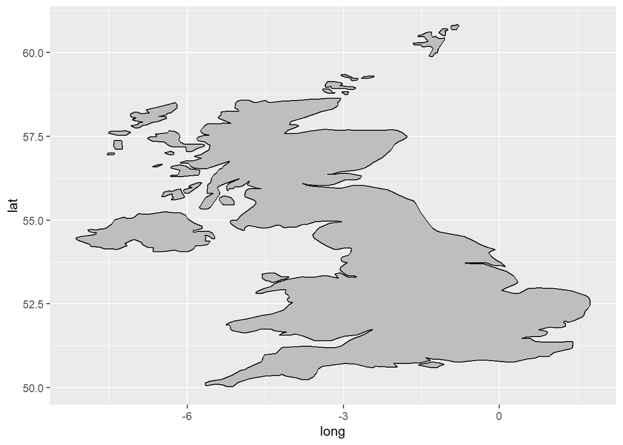

```r
# Load UK map
ukmap <- map_data("world", region = "UK")

ukmap <- ggplot() +
 geom_polygon(data = ukmap, aes(x = long, y = lat, group = group), fill = "grey", color = "black")

print(ukmap)
```

5.2 Secondly, I added my data points and added a title to the colour range bar at the side of the map.

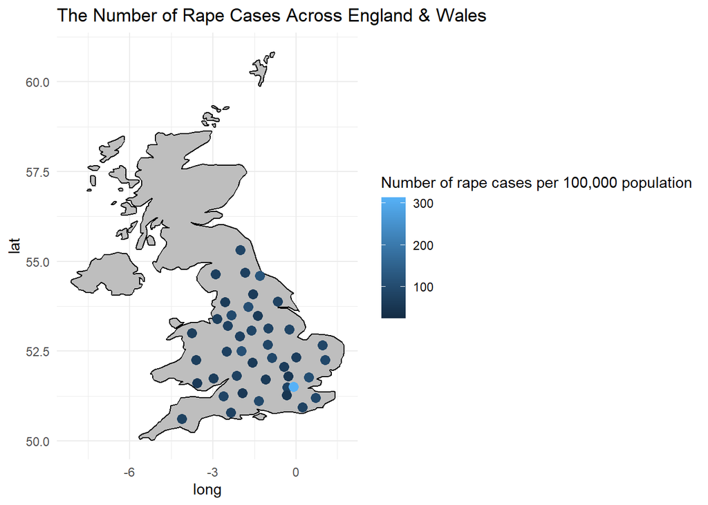

```r
# Adding the data points to the map
map <- ukmap + geom_point(data = merged_data, aes(x = long, y = lat, color = value), size = 3) +
 scale_colour_continuous(name = "Number of rape cases per 100,000 population") +
 theme_minimal() +
  labs(title = "The Number of Rape Cases Across England & Wales")

print(map)
```

5.3 Thirdly, I wanted to change the colour of the data points and the value of the colour range bar to better distinguish the values on the map. This would make it easier to visualise the difference in the number of offences across England and Wales.

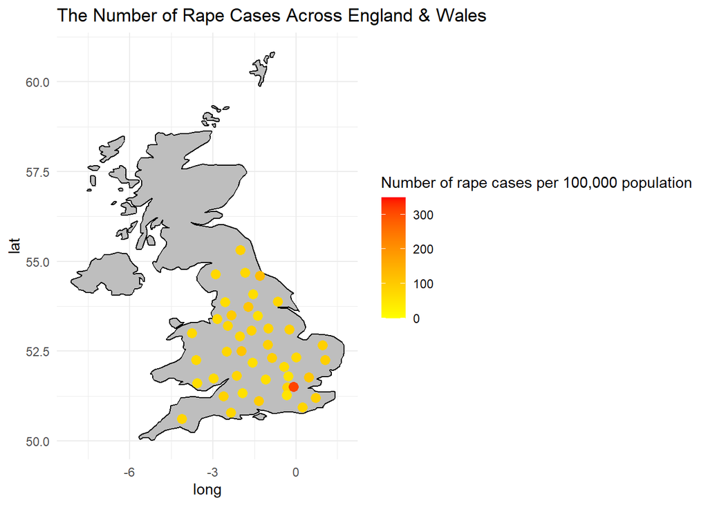

```r
# Changing the colour of the data points
map <- map + geom_point(data = merged_data, aes(x = long, y = lat, color = value), size = 3) +
 scale_colour_continuous(name = "Number of rape cases per 100,000 population", low = "yellow", high = "red", limit = c(0, 350)) +
 theme_minimal() +
  labs(title = "The Number of Rape Cases Across England & Wales")

print(map)
```

5.4 Due to the fact that this data set does not include Scotland and leaves the top portion looking empty. I believe it would look better if I left that land area out by placing a limitation in the x and y-axis.

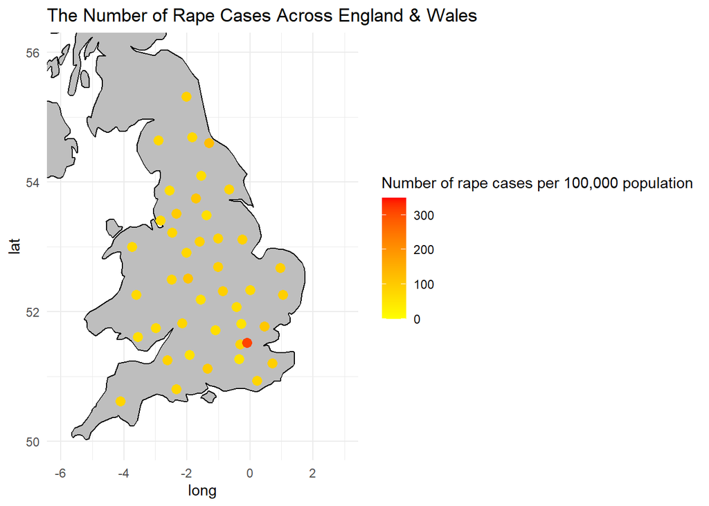

```r
# Changing the the x and y axis to exclude Scotland
map <- map +  coord_cartesian(xlim = c(-6, 3), ylim = c(50, 56))

print(map)
```

```r
#Animating the graph over the years
#Creating the interactive side panel
side_bar <- fluidPage(
    titlePanel("The Number of Rape Cases Across England & Wales"),
    sidebarLayout(
        sidebarPanel(
            selectInput("year", "Select Year:", choices = unique(merged_data$time_period))
        ),
        mainPanel(
            plotOutput("map")
        )
    )
)

#Creating the final graph
animated_map <- function(input, output) {
    output$map <- renderPlot({
        ukmap <- map_data("world", region = "UK")
        ggplot() +
            geom_polygon(data = ukmap, aes(x = long, y = lat, group = group), fill = "grey", color = "black") +
            geom_point(data = merged_data[merged_data$time_period == input$year, ],
                       aes(x = long, y = lat, color = value), size = 3) +
            scale_colour_continuous(name = "Number of rape cases per 100,000 population", low = "yellow", high = "red", limits = c(0, 350)) +
            theme_minimal() +
            labs(title = paste("Year -", input$year))
    })
}

# Run the application
shinyApp(ui = side_bar, server = animated_map)
```

Shiny applications not supported in static R Markdown documents

## 7. Limitations

I believe that one of the limitations to visualising the data in this way is that it was sometimes more challenging to see distinct differences in the colours of the data points because the values were so similar.

## 8. Future Directions

I think one could compare these values to other countries or compare each of these geographical areas to the national averages across the years. This is also a data set that will be updated every year so it would be interesting to see how the trends change over the next few years, especially with the rise in social movements.